# KDD SoilGrids — propiedades del suelo y rendimiento

Los Vochos · Reto AgroCebada FIRA 2026

2026-10-04

# Qué se analizó

Las **336** capas de [SoilGrids 2.0](https://www.isric.org/explore/soilgrids) (ISRIC) recortadas al área de las 197 parcelas del reto (Homolosine, 250 m). Valores convertidos a unidades físicas. Una fila por parcela en el CSV extendido.

Solo las **138** parcelas de entrenamiento entran a las correlaciones con el rendimiento. Es exploración, no prueba.

| Servicio | Capas con estadística zonal |
| --- | --- |
| bdod | 30 |
| cec | 30 |
| cfvo | 30 |
| clay | 30 |
| nitrogen | 30 |
| ocd | 30 |
| ocs | 5 |
| phh2o | 30 |
| sand | 30 |
| silt | 30 |
| soc | 30 |
| wrb | 31 |

# Calidad

| capas | con_na | mediana_distintos | min_distintos | max_distintos |
| --- | --- | --- | --- | --- |
| 336 | 0 | 191 | 1 | 197 |

Píxeles distintos por parcela: la mediana es 191. Capas casi constantes aportan poco (p. ej. algunas WRB con probabilidad casi 0 en la zona).

# Correlación con el rendimiento

Dos lecturas: **global** (138 parcelas) e **intra-estado** (tras restar la media de cada estado). Cuando la segunda cae a cero, la variable describe el estado más que el lote.

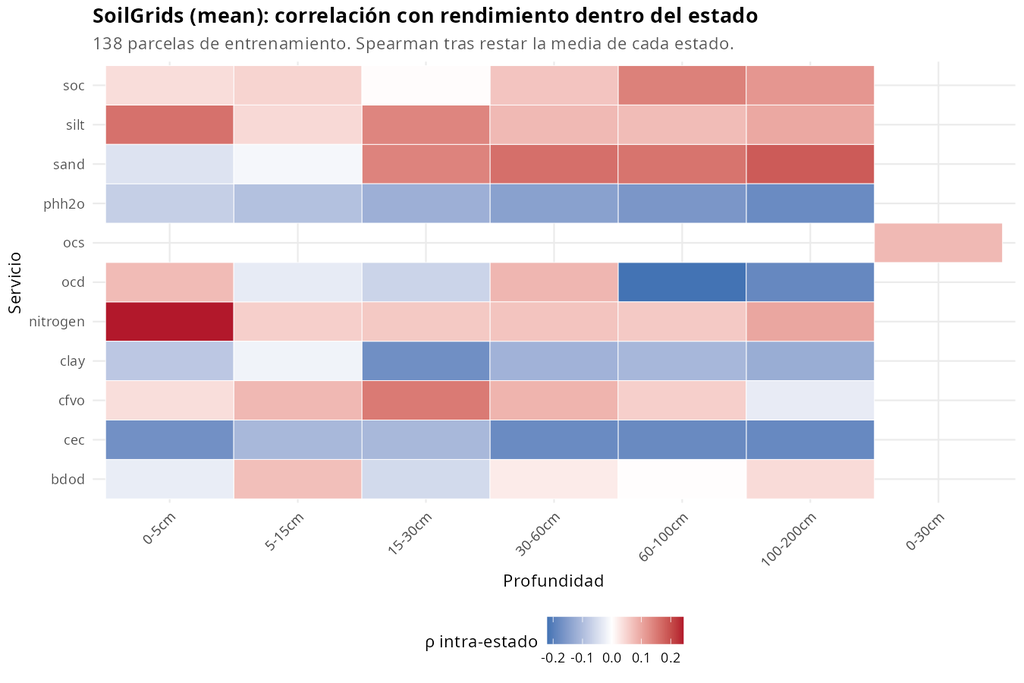

Heatmap de ρ intra-estado para las capas mean por servicio y profundidad.

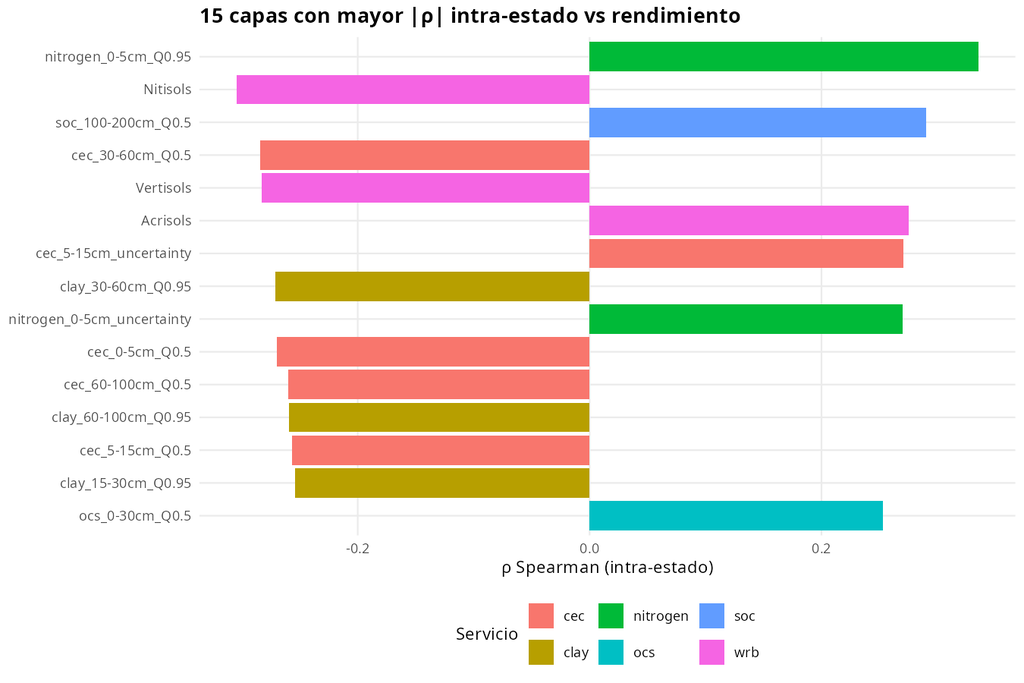

Top 15 capas por |ρ| intra-estado.

| Capa | Servicio | Estadístico | ρ global | ρ intra | p BH intra |
| --- | --- | --- | --- | --- | --- |
| nitrogen_0-5cm_Q0.95 | nitrogen | Q0.95 | 0.60 | 0.34 | 0.019 |
| Nitisols | wrb | otro | -0.09 | -0.30 | 0.044 |
| soc_100-200cm_Q0.5 | soc | Q0.5 | 0.60 | 0.29 | 0.044 |
| cec_30-60cm_Q0.5 | cec | Q0.5 | -0.29 | -0.28 | 0.044 |
| Vertisols | wrb | otro | -0.50 | -0.28 | 0.044 |
| Acrisols | wrb | otro | 0.23 | 0.27 | 0.044 |
| cec_5-15cm_uncertainty | cec | uncertainty | 0.49 | 0.27 | 0.044 |
| clay_30-60cm_Q0.95 | clay | Q0.95 | 0.08 | -0.27 | 0.044 |
| nitrogen_0-5cm_uncertainty | nitrogen | uncertainty | 0.21 | 0.27 | 0.044 |
| cec_0-5cm_Q0.5 | cec | Q0.5 | -0.38 | -0.27 | 0.044 |
| cec_60-100cm_Q0.5 | cec | Q0.5 | -0.01 | -0.26 | 0.058 |
| clay_60-100cm_Q0.95 | clay | Q0.95 | 0.08 | -0.26 | 0.058 |

Lectura breve:

- **Nitrógeno 0–5 cm (mean)** destaca dentro del estado (ρ ≈ 0.24) y también en global.
- Muchas capas con ρ global alto (SOC, fragmentos, WRB) **se debilitan dentro del estado**: son proxies territoriales (94 capas etiquetadas así en el ranking).
- Los cuantiles a veces ganan al mean en |ρ| crudo; el ranking prioriza mean cuando ya captura la señal y evita inflar columnas.

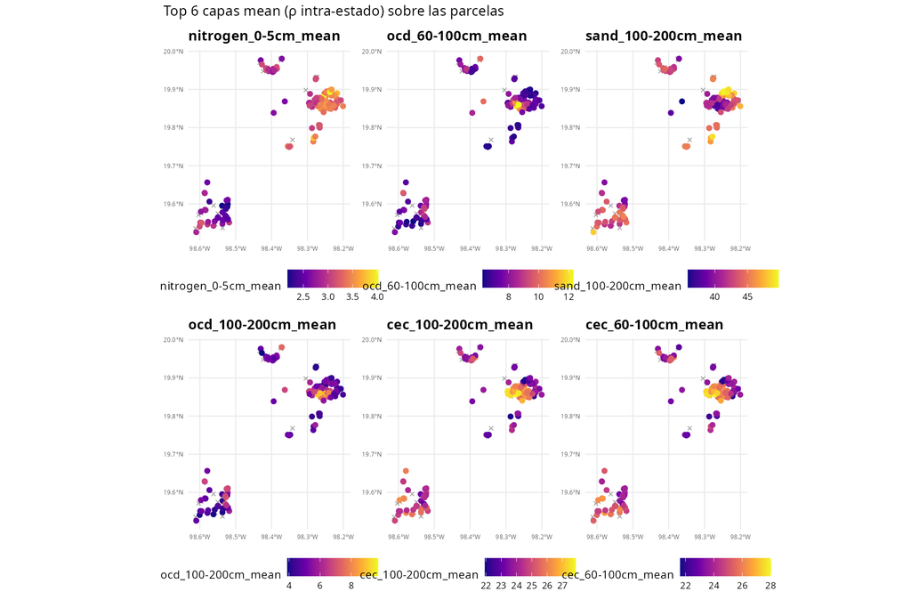

Mapas de las 6 capas mean con mayor |ρ| intra-estado.

# Redundancia y PCA

Con las 61 capas *mean*, `|ρ| ≥ 0.9` las agrupa en 27 grupos. Textura (arcilla/arena/limo) y carbono/nitrógeno están muy ligados.

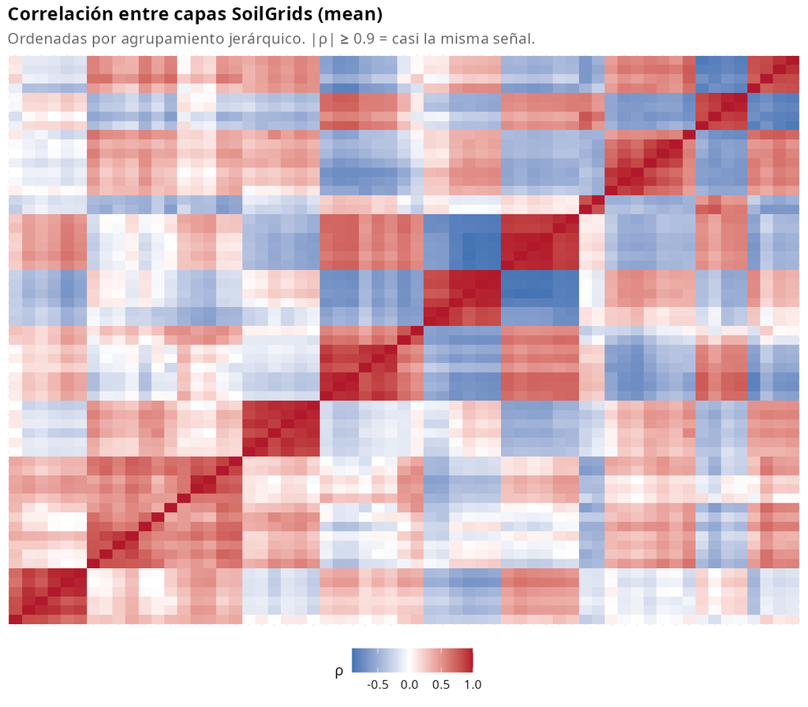

Matriz de correlación entre capas mean.

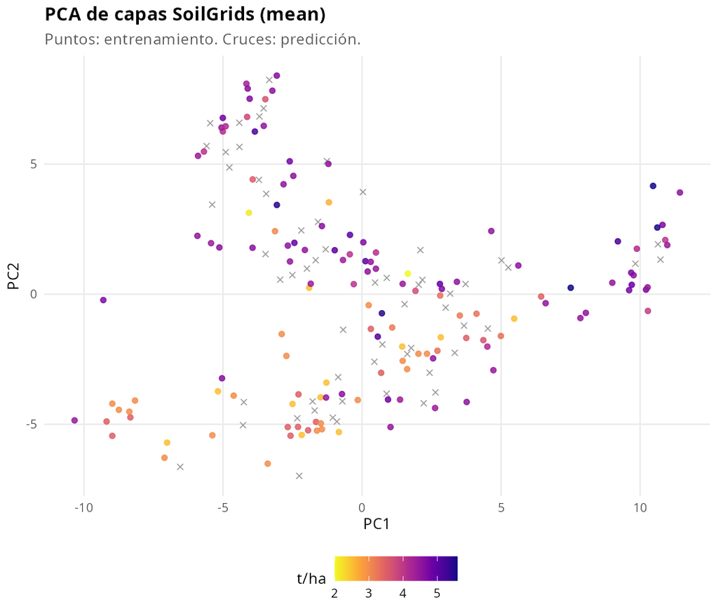

Parcelas en PC1–PC2 de SoilGrids mean.

Las primeras 5 componentes explican 83 % de la varianza de las capas mean.

# Ranking: qué incluir

Criterios (en orden): |ρ| intra-estado con BH < 0.1; variación entre parcelas; un representante por grupo redundante; preferir `mean`.

| Recomendación | Capas |
| --- | --- |
| descartar | 146 |
| proxy_de_estado | 94 |
| solo_control_calidad | 57 |
| redundante_de_incluido | 17 |
| considerar | 10 |
| descartar_poca_variacion | 1 |
| incluir | 1 |

## Lista recomendada (corta)

| Capa | Servicio | Profundidad | ρ intra | p BH | ρ global | Distintos |
| --- | --- | --- | --- | --- | --- | --- |
| nitrogen_0-5cm_mean | nitrogen | 0-5cm | 0.24 | 0.082 | 0.65 | 138 |
| ocd_60-100cm_mean | ocd | 60-100cm | -0.22 | 0.12 | 0.03 | 138 |
| sand_100-200cm_mean | sand | 100-200cm | 0.19 | 0.2 | 0.02 | 138 |
| ocd_100-200cm_mean | ocd | 100-200cm | -0.18 | 0.2 | 0.13 | 136 |
| cec_100-200cm_mean | cec | 100-200cm | -0.18 | 0.2 | 0.00 | 137 |
| phh2o_100-200cm_mean | phh2o | 100-200cm | -0.18 | 0.2 | -0.22 | 119 |
| cec_0-5cm_mean | cec | 0-5cm | -0.17 | 0.24 | 0.07 | 138 |
| silt_0-5cm_mean | silt | 0-5cm | 0.16 | 0.28 | 0.34 | 138 |
| cfvo_15-30cm_mean | cfvo | 15-30cm | 0.15 | 0.32 | 0.42 | 138 |
| soc_60-100cm_mean | soc | 60-100cm | 0.14 | 0.35 | 0.51 | 138 |
| nitrogen_100-200cm_mean | nitrogen | 100-200cm | 0.10 | 0.52 | 0.37 | 137 |

**Incluir con prioridad** (señal intra-estado más clara): `nitrogen_0-5cm_mean`.

**Considerar** (pista, p BH > 0.1 o efecto menor): OCD profundo, arena profunda, CIC, pH profundo, limo superficial, fragmentos, SOC profundo.

**No priorizar** en la primera ola de CSVs: la mayoría de cuantiles e incertidumbres (salvo control de calidad), ni las 94 capas que actúan como proxy de estado.

# Comparación con INEGI (WRB)

| edaf_grupo | sg_MostProbable | parcelas |
| --- | --- | --- |
| PHAEOZEM | 20.000000 | 53 |
| PHAEOZEM | 20.000000 | 22 |
| PLANOSOL | 20.000000 | 20 |
| PHAEOZEM | 20.000000 | 18 |
| UMBRISOL | 18.000000 | 6 |
| PLANOSOL | 20.000000 | 5 |
| PHAEOZEM | 20.000000 | 3 |
| PHAEOZEM | 18.000000 | 2 |
| PLANOSOL | 20.000000 | 2 |
| UMBRISOL | 20.000000 | 2 |
| VERTISOL | 20.000000 | 2 |
| VERTISOL | 20.000000 | 2 |
| ANDOSOL | 18.000000 | 1 |
| ANDOSOL | 18.000000 | 1 |
| ANDOSOL | 18.836613 | 1 |
| PHAEOZEM | 3.000000 | 1 |
| PHAEOZEM | 9.319665 | 1 |
| PHAEOZEM | 12.718771 | 1 |
| PHAEOZEM | 15.490702 | 1 |
| PHAEOZEM | 16.396599 | 1 |
| PHAEOZEM | 16.958457 | 1 |
| PHAEOZEM | 17.639340 | 1 |
| PHAEOZEM | 18.018332 | 1 |
| PHAEOZEM | 18.045392 | 1 |
| PHAEOZEM | 18.055646 | 1 |
| PHAEOZEM | 18.183483 | 1 |
| PHAEOZEM | 18.280322 | 1 |
| PHAEOZEM | 18.394969 | 1 |
| PHAEOZEM | 18.557655 | 1 |
| PHAEOZEM | 18.622627 | 1 |
| PHAEOZEM | 18.686748 | 1 |
| PHAEOZEM | 18.689077 | 1 |
| PHAEOZEM | 18.711134 | 1 |
| PHAEOZEM | 18.740800 | 1 |
| PHAEOZEM | 18.861401 | 1 |
| PHAEOZEM | 18.864560 | 1 |
| PHAEOZEM | 19.004342 | 1 |
| PHAEOZEM | 19.189221 | 1 |
| PHAEOZEM | 19.288798 | 1 |
| PHAEOZEM | 19.374014 | 1 |
| PHAEOZEM | 19.474503 | 1 |
| PHAEOZEM | 19.555552 | 1 |
| PHAEOZEM | 19.662837 | 1 |
| PHAEOZEM | 19.707610 | 1 |
| PHAEOZEM | 19.874179 | 1 |
| PHAEOZEM | 19.875723 | 1 |
| PHAEOZEM | 19.924662 | 1 |
| PHAEOZEM | 19.948774 | 1 |
| PHAEOZEM | 19.962129 | 1 |
| PHAEOZEM | 19.998617 | 1 |
| PHAEOZEM | 20.000000 | 1 |
| PHAEOZEM | 24.091802 | 1 |
| PHAEOZEM | 29.000000 | 1 |
| PLANOSOL | 17.738891 | 1 |
| UMBRISOL | 4.968599 | 1 |
| UMBRISOL | 8.462970 | 1 |
| UMBRISOL | 10.385078 | 1 |
| UMBRISOL | 14.426509 | 1 |
| UMBRISOL | 18.000000 | 1 |
| UMBRISOL | 18.027834 | 1 |
| UMBRISOL | 18.105760 | 1 |
| UMBRISOL | 18.241730 | 1 |
| UMBRISOL | 18.295105 | 1 |
| UMBRISOL | 18.555923 | 1 |
| UMBRISOL | 18.565904 | 1 |
| UMBRISOL | 18.690317 | 1 |
| UMBRISOL | 18.751925 | 1 |
| UMBRISOL | 18.753385 | 1 |
| UMBRISOL | 20.259166 | 1 |
| UMBRISOL | 26.134792 | 1 |
| VERTISOL | 18.789985 | 1 |
| VERTISOL | 20.000000 | 1 |

SoilGrids aporta **probabilidades** por grupo WRB y propiedades continuas a 250 m; INEGI aporta un polígono dominante a 1:250 000. No sustituyen: se complementan (y ambos se entrelazan con el estado).

# Cómo regenerar

```bash
bash analisis/correr.sh soilgrids
```

CSV: `DATASETS_EXTERNOS/despensa_extendida/parcelas_despensa_extendida_soilgrids_v1.csv`. Lectura corta: `analisis/RESUMEN_DATOS_SOILGRIDS.md`.